# Week 05 - Day 02 - Homework

# MVP

Question 1.

Load in the libraries you need, and look at the backpack data. Take note of variable names and dimensions.

```r
library(CodeClanData)
library(tidyverse)

backpack <- CodeClanData::backpack
colnames(backpack)
```

```
[1] "backpack_weight" "body_weight"     "ratio"           "back_problems"   "major"           "year"            "sex"             "status"          "units"
```

```r
nrow(backpack)
```

```
[1] 100
```

```r
ncol(backpack)
```

```
[1] 9
```

Question 2.

What is the distribution of backpack weights that students are carrying? Choose an appropriate graph to show the distribution.

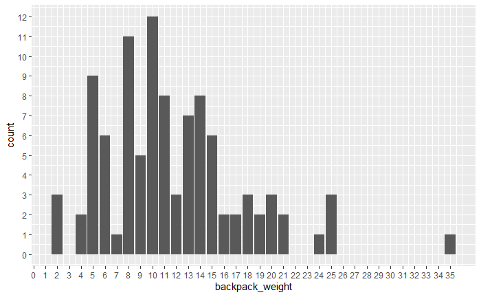

```r
backpack %>%
  ggplot(aes(x = backpack_weight)) +
  geom_bar() +
  scale_x_continuous(breaks = c(0:35))+
  scale_y_continuous(n.breaks = 10)
```

```r
NA
```

This shows that most of the students backpacks weigh between 5kg and 15kg (kg is assumed)

Question 3.

Are there differences in backpack weight between sex?

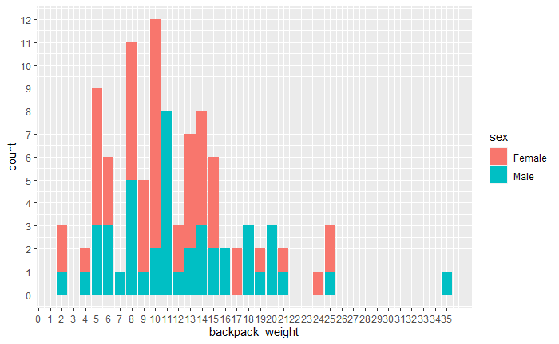

This shows that there isn’t much difference in backpack weight between sexs

Question 4.

What is the relationship between body weight and backpack weight?

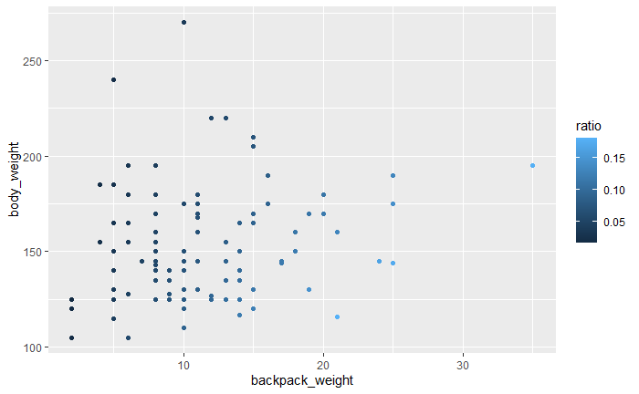

This suggests that people tend to have a lighter backpack if they weigh less

Question 5.

Is this relationship different between men and women? Choose an appropriate plot and interpret your findings.

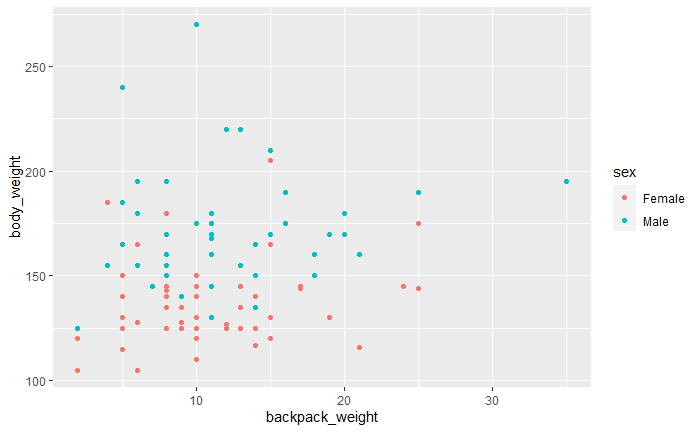

This shows that the relationship between bodyweight and backpack weight does not seem to differ much between sexes

Question 6.

What proportion of students report back pain?

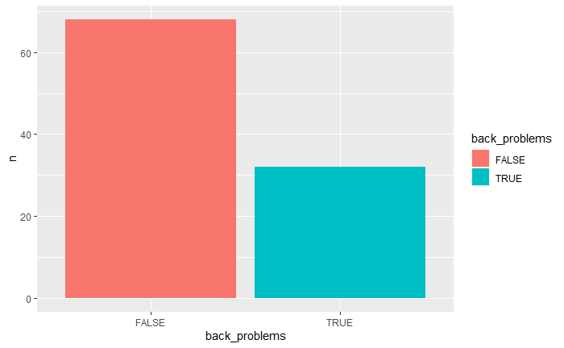

This shows that around 70% of students do not report back pain

Question 7.

Is this proportion different between men and women?

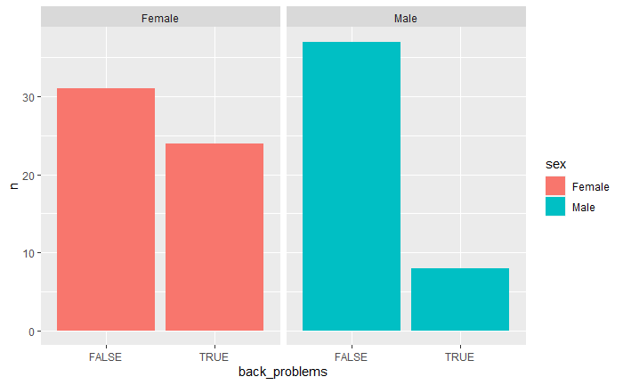

This shows that while it is still true that when looking at both sexes, the majority do not report back problems. However, this proportion is smaller when looking at females

Question 8.

Now you’ve investigated your data separately, create plots to describe the relationship between backpack weight, body weight, gender and reported backpain.

Try both backpack_weight and body_weight as well as the ratio.

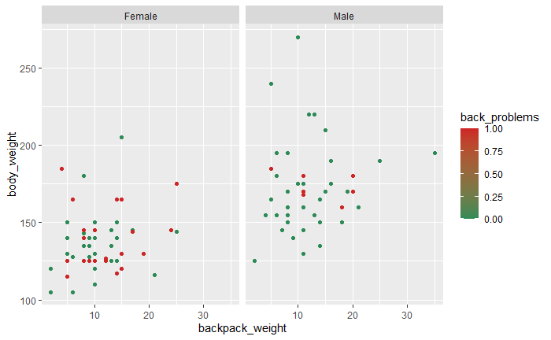

In this case, No back pain is represented as green while reported back pain is red. The graph shows that backpain is more common in Females, although there appears to be no direct relationship with bodyweight or backpack weight Males show less backpain, and is reported only where bodyweight trends upwards.

# EXT

Question 1.

Does reported backpain differ across the year groups? Ignore year 0 in your data.

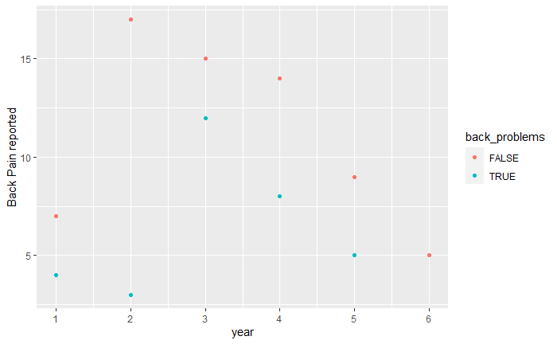

This shows that back pain is reported most commonly from years 3 to 5, but in all years, it is more common for students to not report back pain